# Cnidaria only - 126 CS

2023-10-11

## Script to work on analyses for causes paper

##Taxonomic work is needed? # Morpho differentiation types: More CS sl than CS ss overall? # Need to find expectations and test against 50:50 mark

```
##
##  Pearson's Chi-squared test with Yates' continuity correction
##
## data:  cbind(expected, observed)
## X-squared = 6.7103, df = 1, p-value = 0.009586
```

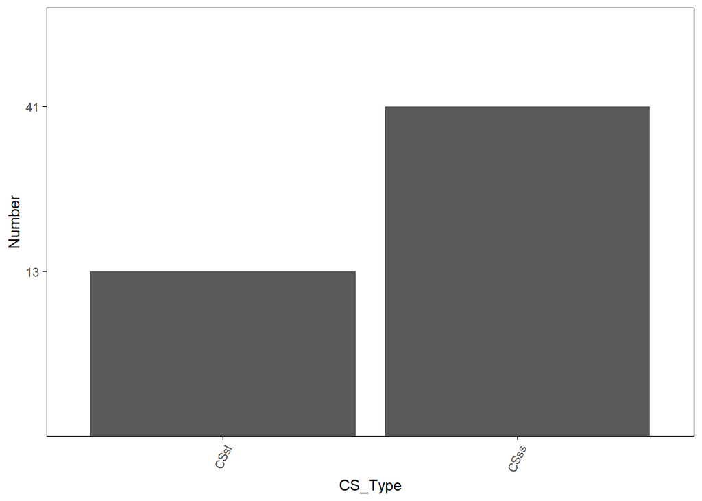

Significantly more ss than sl; reject hypothesis.

# Available technology – More diagnostic differences in species described earlier?

```
##
##        FALSE TRUE
##   1750     2    4
##   1760     1    3
##   1770     0    1
##   1780     0    1
##   1790     0    2
##   1810     0    1
##   1820     2    4
##   1840     1    2
##   1860     1    0
##   1870     0    1
##   1880     0    2
##   1890     0    1
##   1900     0    1
##   1910     0    2
##   1950     0    1
##   1960     1    0
##   1990     1    1
##   2000     0    3
##   2010     2    4
```

```
##
##  Pearson's Chi-squared test
##
## data:  decademorpho$decade and decademorpho$CSss
## X-squared = 12.965, df = 18, p-value = 0.7937
```

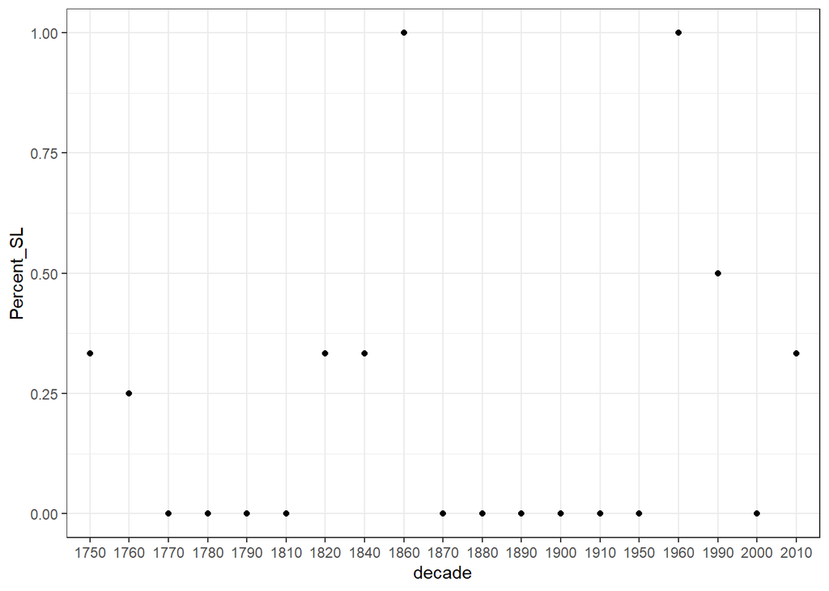

There is no trend here. Hypothesis not supported.

# Prevailing theories of nature and species origins - More CS in fragmented habitats in species described before Darwin?

```
##
##             10 100 1000 25  5
##   1756-1859 24   8    9  6  6
##   1860-1980  7   5   12 13  3
##   1981-2020 10   0    4  0  2
```

```
##
##  Pearson's Chi-squared test
##
## data:  breaks_HKK$decade_bin and breaks_HKK$HKK
## X-squared = 21.422, df = 8, p-value = 0.006106
```

```
##                   10       100      1000        25         5
## pre_Darwin 0.4528302 0.1509434 0.1698113 0.1132075 0.1132075
## pre_Kimura 0.1750000 0.1250000 0.3000000 0.3250000 0.0750000
## modern     0.6250000 0.0000000 0.2500000 0.0000000 0.1250000
```

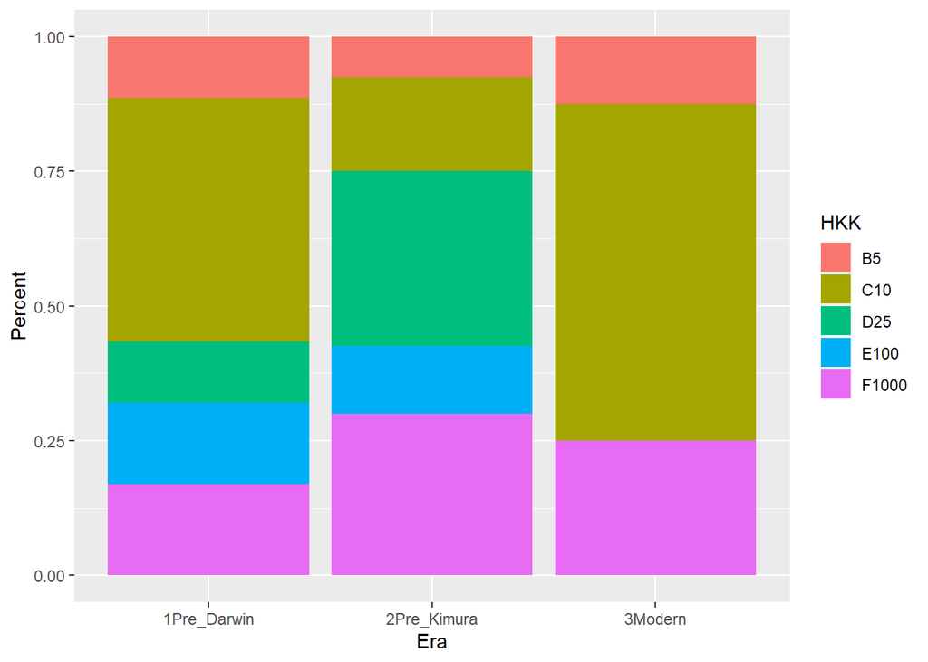

This is significant but messy. Patterns not very clear.

# Accessibility of habitat when species described - Percentage of CS in inaccessible habitats higher in earlier spp?

```
##
##        Difficult Easy Normal
##   1750         2    2      6
##   1760         1    0      4
##   1770         0    1      2
##   1780         0    0      2
##   1790         0    0      4
##   1800         1    0      0
##   1810         2    0      1
##   1820         0    2      6
##   1830         1    1      3
##   1840         1    0      9
##   1850         0    0      3
##   1860         1    0      6
##   1870         0    1      8
##   1880         1    0      7
##   1890         0    0      5
##   1900         1    0      2
##   1910         1    0      1
##   1920         0    0      2
##   1930         0    1      0
##   1940         0    1      0
##   1950         1    0      0
##   1960         0    0      1
##   1990         0    0      4
##   2000         0    0      4
##   2010         0    2      6
```

```
##
##  Pearson's Chi-squared test
##
## data:  decadeAccess$decade and decadeAccess$Access
## X-squared = 68.416, df = 48, p-value = 0.02799
```

[figure not shown]

Significant but no trend, no real support for hypothesis.

## In sum, when we only look at species with CS (i.e. our database), the effect of taxonomic work goes away. This is interesting since that was the strongest effect in paper 1. THIS IS STILL TRUE with the cnidarians.

## Effect of recent divergence - dispersal

# Larval type – Planktotrophic/pelagic larvae leads to less CS/NS)?

Note1: for this I’m working with a separate surveylarv input file where I have corrected larval types to pt, lt, dd, and removed all others, including cases where there are multiple types checked. (Most of those cases are where the two CS have different larvae.) This left 75 CS with larval info.

Note2: the data fail the homoscedasticity test (Bartlett’s) so I’ve used a nonparametric Kruskal-Wallis test to see if CS/NS is different among groups.

```
##       DD       LT       PT
## 2.888889 3.510638 2.736842
```

```
##       DD       LT       PT
## 1.452966 2.185648 1.240166
```

```
##
##  Kruskal-Wallis rank sum test
##
## data:  as.numeric(larv_NbCS$Nb_CS) and larv_NbCS$Larv_type
## Kruskal-Wallis chi-squared = 1.7444, df = 2, p-value = 0.418
```

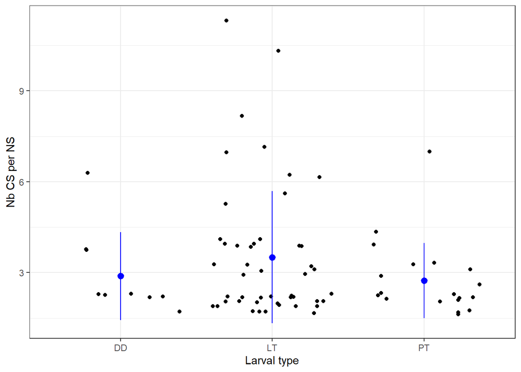

No differences; hypothesis not supported.

# High HKK leads to more CS ss – testing this based on Nb_CS per HKK.

Note: data again failed homoscedasticity, using Kruskal Wallis test

```
##        5       10       25      100     1000
## 2.750000 2.772727 2.782609 3.500000 3.733333
```

```
##        5       10       25      100     1000
## 1.484771 1.273407 1.166055 2.175033 2.625253
```

```
##
##  Kruskal-Wallis rank sum test
##
## data:  HKK_NbCS$Nb_CS and HKK_NbCS$HKKv3
## Kruskal-Wallis chi-squared = 5.2392, df = 4, p-value = 0.2636
```

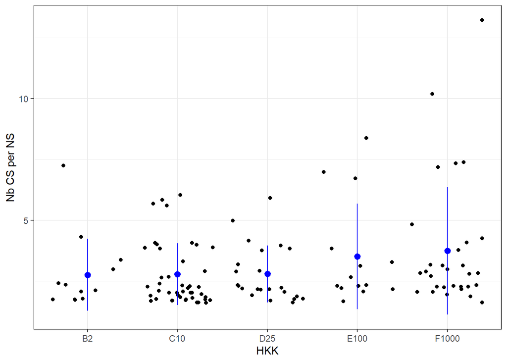

Result: No differences; hypothesis not supported.

## In sum, no support for the role of recent divergence as measured by a proxy of dispersal when considering only the cnidarians

# More stable environments = more CSss or statistical differences

Note: stable = pelagic, deepsea, cave, coralreef; not stable = coastal, intertidal, estuarine, seagrass

```
##
##         FALSE TRUE
##   FALSE     4    9
##   TRUE      7   34
```

```
##
##  Pearson's Chi-squared test with Yates' continuity correction
##
## data:  stable_hab$CSss and stable_hab$Stable
## X-squared = 0.45323, df = 1, p-value = 0.5008
```

```
##                FALSE      TRUE
## CSss_total 0.6363636 0.7906977
## CSsl_total 0.3636364 0.2093023
```

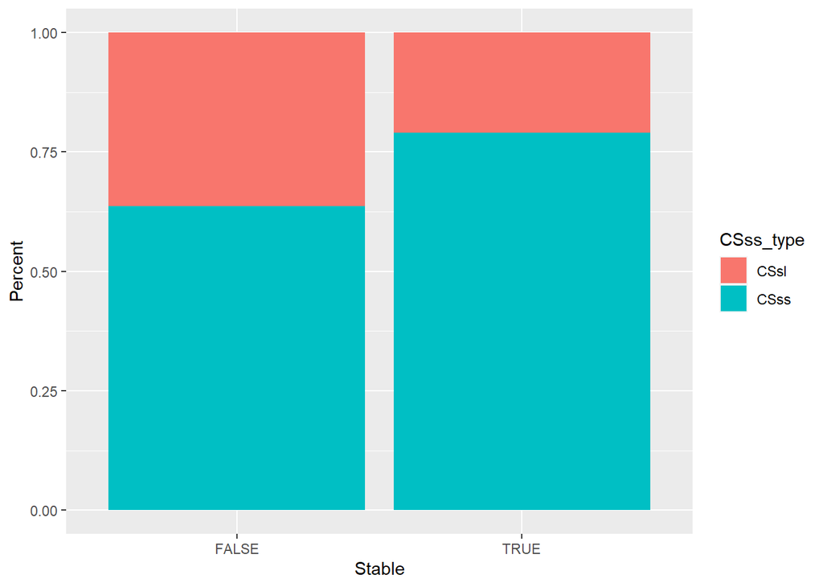

Result: No difference; hypothesis not supported.

# Note also that stabilizing selection predicts more CSss than CSsl, which is what we find (see above).

## In sum, we have some support for this idea.

## High Ne (neutral hypotheses)

# Reproductive investment - Low reproductive investment leads to more statistical divergence? (Repro. investment proxy for Ne)

Note1: Again this uses the surveylarv dataset with hand cleaning. Note2: Planktotrophic = LOW; Lecithotrophic, Brooding, DD = HIGH; If a spp could be both low and high, have marked it NA (is usually bc the CS have different larval types). Anything else got marked NA to be conservative. Note3: Only 30 cases are considered here, meaning that is where we have morphological data AND larval type data AND Cnidarian

```
##
##                      HIGH LOW
##   Diagnostic            5   3
##   No differentiation    4   4
##   Statistic             9   5
```

```
##
##  Pearson's Chi-squared test
##
## data:  surveylarv$Morpho_diff and surveylarv$Repro_invest
## X-squared = 0.46131, df = 2, p-value = 0.794
```

Result: not significant.

# High HKK leads to more CS ss (HKK as proxy for Ne)

```
##
##                       5 10 25 100 1000
##   Diagnostic          2  5  2   1    3
##   No differentiation  3  7  0   2    4
##   Statistic           1  7  3   3   11
```

```
##                    5        10  25       100      1000
## stat_total 0.1666667 0.3684211 0.6 0.5000000 0.6111111
## diag_total 0.3333333 0.2631579 0.4 0.1666667 0.1666667
## nod_total  0.5000000 0.3684211 0.0 0.3333333 0.2222222
```

```
##
##    5   10   25  100 1000
##    6   19    5    6   18
```

```
##
##  Pearson's Chi-squared test
##
## data:  surveymorpho$Morpho_diff and surveymorpho$HKKv3
## X-squared = 6.9221, df = 8, p-value = 0.5451
```

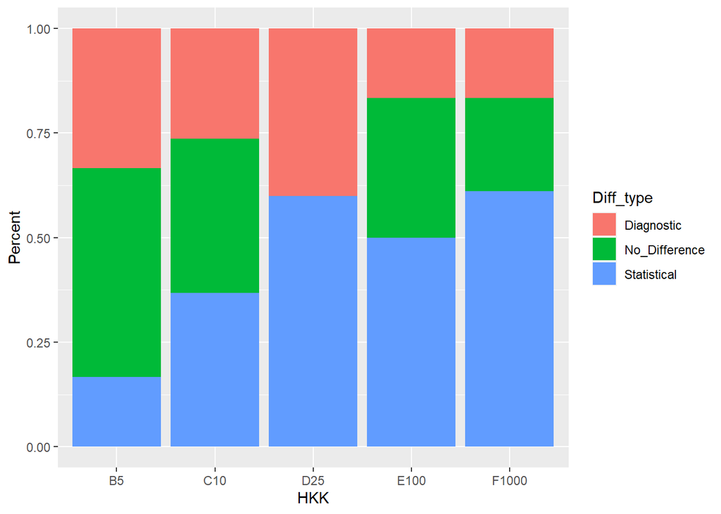

```
##
##        FALSE TRUE
##   5        2    4
##   10       5   14
##   25       2    3
##   100      1    5
##   1000     3   15
```

```
##
##  Pearson's Chi-squared test
##
## data:  surveymorpho$HKKv3 and surveymorpho$CSss
## X-squared = 1.7479, df = 4, p-value = 0.782
```

```
##                    5        10  25       100      1000
## CSss_total 0.6666667 0.7368421 0.6 0.8333333 0.8333333
## CSsl_total 0.3333333 0.2631579 0.4 0.1666667 0.1666667
```

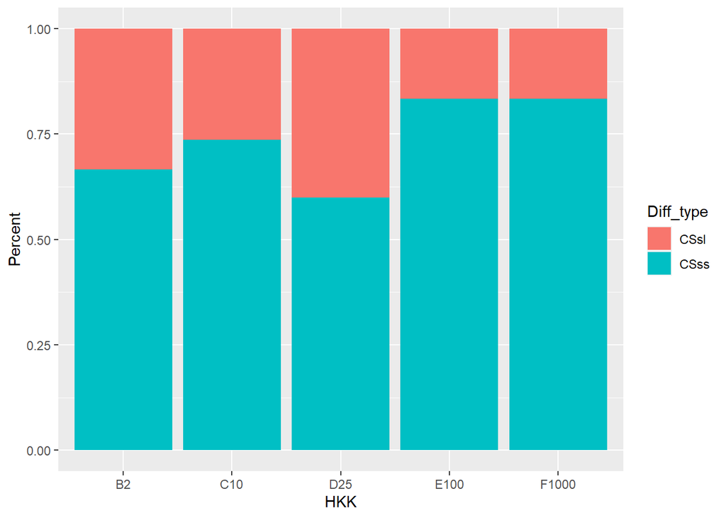

Results: Not significant; no support. Most Cnidarians are either at n=10 (reefs) or n=1000 (jellies).

## In sum, we do not see support for hypotheses related to Ne.

## Hypothesis: effect of recent divergence – More sympatric than allopatric CS/NS for a given Nsg?

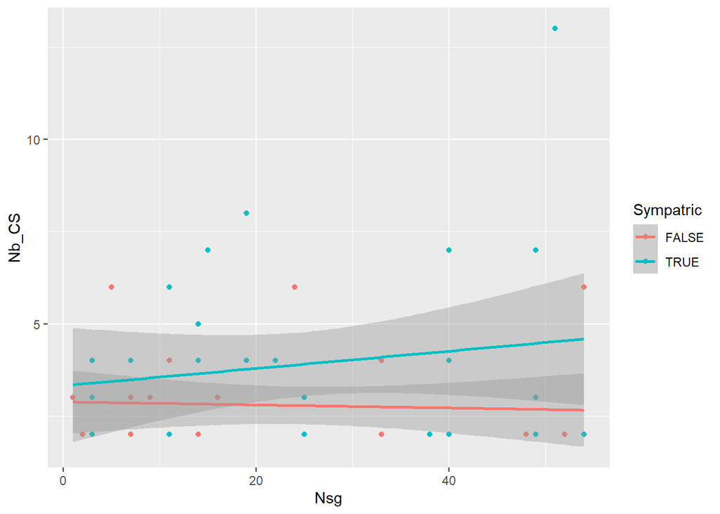

```
## ANOVA Table (type II tests)
##
##      Effect DFn DFd     F     p p<.05      ges
## 1     Nb_CS   1  57 0.400 0.530       0.007000
## 2 Sympatric   1  57 0.006 0.936       0.000114
```

These results aren’t statistically significant (ANCOVA) but the graph is in line with the hypothesis. Marginal support.

## Selection against hybrids – More diagnostic differences in sympatry than allopatry?

```
##
##         FALSE TRUE
##   FALSE     6    4
##   TRUE     11   18
```

```
##
##  Pearson's Chi-squared test with Yates' continuity correction
##
## data:  surveymorpho$CSss and surveymorpho$Sympatric
## X-squared = 0.71206, df = 1, p-value = 0.3988
```

```
##                FALSE      TRUE
## CSss_total 0.6470588 0.8181818
## CSsl_total 0.3529412 0.1818182
```

[figure not shown]

Result: hypothesis not supported

## Importance of biological traits

# More diagnostic traits with hard skeleton?

```
##
##                       N  Y
##   Diagnostic          6  7
##   No differentiation  7  9
##   Statistic          15 10
```

```
##
##  Pearson's Chi-squared test
##
## data:  surveymorpho$Morpho_diff and surveymorpho$hard_skeleton
## X-squared = 1.2546, df = 2, p-value = 0.534
```

```
##                    N         Y
## stat_total 0.5357143 0.3846154
## diag_total 0.2142857 0.2692308
## nod_total  0.2500000 0.3461538
```

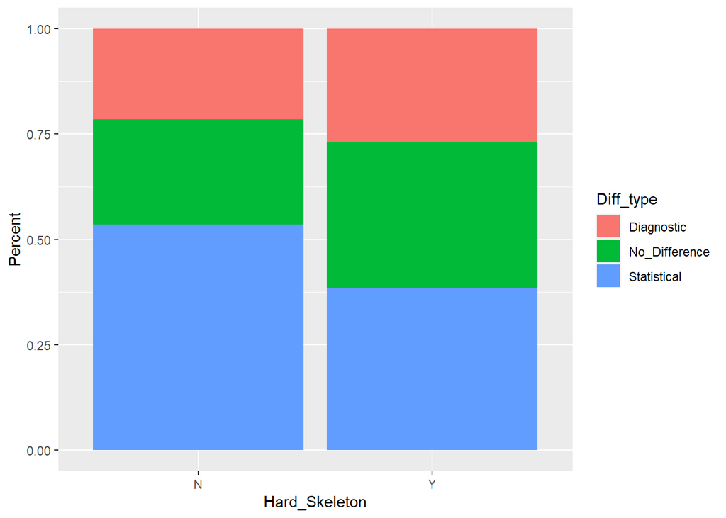

Not significant; no support. Also true if I just test CSss/sl.

# More diagnostic traits with image vision?

```
##
##                       N  Y
##   Diagnostic         13  0
##   No differentiation 16  0
##   Statistic          25  0
```

```
##                    N   Y
## stat_total 0.4629630 NaN
## diag_total 0.2407407 NaN
## nod_total  0.2962963 NaN
```

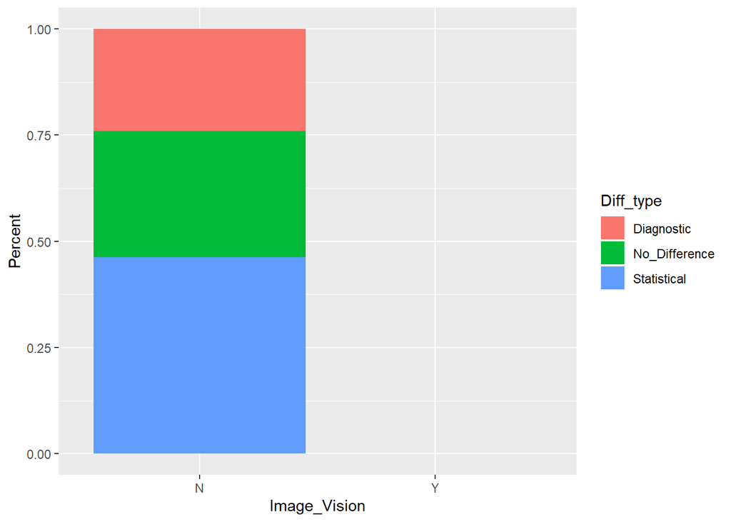

Result: No image vision; no test.

# More diagnostic traits with internal fertilization?

```
##
##                       B  E  I
##   Diagnostic          0 12  1
##   No differentiation  0 16  0
##   Statistic           0 25  0
```

```
##
##  Pearson's Chi-squared test
##
## data:  surveymorpho$Morpho_diff and surveymorpho$ferti
## X-squared = 3.2134, df = 2, p-value = 0.2006
```

```
##              B         E I
## stat_total NaN 0.4716981 0
## diag_total NaN 0.2264151 1
## nod_total  NaN 0.3018868 0
```

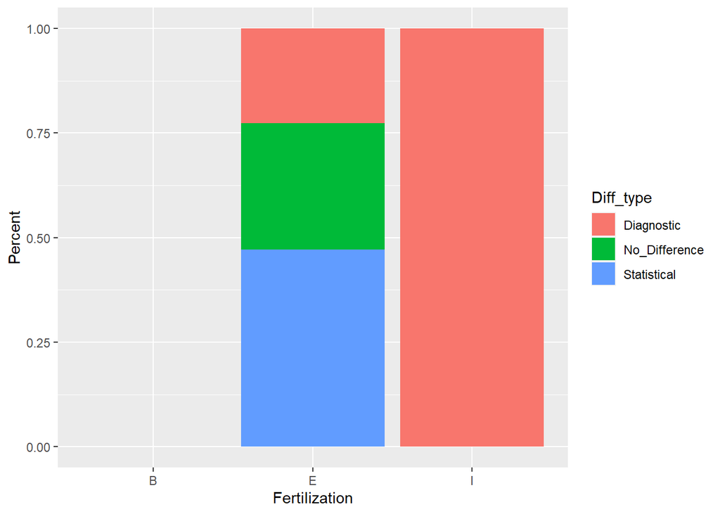

Result: hypothesis not supported. Only ONE internal fertilizer. (Who is this?)

# More diagnostic traits with external genitalia?

```
##
##                       B  N  Y
##   Diagnostic          0 13  0
##   No differentiation  0 16  0
##   Statistic           0 25  0
```

```
##              B         N   Y
## stat_total NaN 0.4629630 NaN
## diag_total NaN 0.2407407 NaN
## nod_total  NaN 0.2962963 NaN
```

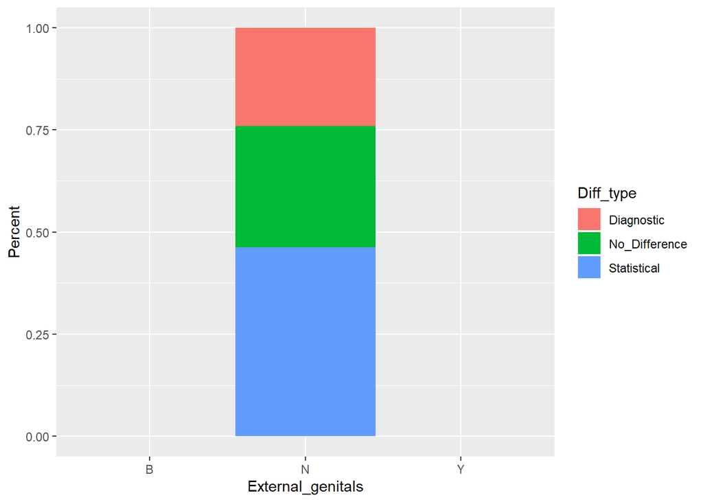

Result: Everyone lacks genitals; no test.

## In sum, no support for the role of biological traits within the cnidarians, but these traits are fixed in this group of species.

## So, overall conclusions: When looking at just the cnidarians, most hypotheses lacking support? Maybe something about taxonomic history. Thought: maybe there’s just so many CS overall in the cnidarians that no other patterns can emerge? Everyone has CS?